# An Introduction to ggplot2

### Scales

- There are a number of ways to change the scales used by the axes
- These notes will simply introduce a few examples
- We begin by creating another summary of the `mendota` data set which we name `mendota_sum2` by counting the number of observations within each 50-year period and first freeze 2-week category in a column `n`
  - the column `p` is the proportion of these counts within each 50-year period
  - the column `pct` are these values as percentages
- Code to create this summary is suppressed.

```
## # A tibble: 15 × 5
## # Groups:   period50 [4]
##    period50  ff_period     n      p   pct
##    <chr>     <fct>     <int>  <dbl> <dbl>
##  1 1855-1900 Nov 16-30     4 0.0870  8.70
##  2 1855-1900 Dec 1-15     17 0.370  37.0
##  3 1855-1900 Dec 16-31    19 0.413  41.3
##  4 1855-1900 Jan 1-15      6 0.130  13.0
##  5 1901-1950 Dec 1-15     14 0.28   28
##  6 1901-1950 Dec 16-31    27 0.54   54
##  7 1901-1950 Jan 1-15      8 0.16   16
##  8 1901-1950 Jan 16-30     1 0.02    2
##  9 1951-2000 Dec 1-15     14 0.28   28
## 10 1951-2000 Dec 16-31    27 0.54   54
## 11 1951-2000 Jan 1-15      9 0.18   18
## 12 2001-2022 Dec 1-15      2 0.0952  9.52
## 13 2001-2022 Dec 16-31     7 0.333  33.3
## 14 2001-2022 Jan 1-15     11 0.524  52.4
## 15 2001-2022 Jan 16-30     1 0.0476  4.76
```

- When we created bar graphs of the first freeze date 2-week categories by 50-year period of the counts, the overall size of the histograms was smaller in the two parts with fewer observations.
- Here we use `geom_bar()` from the winter-level data as above

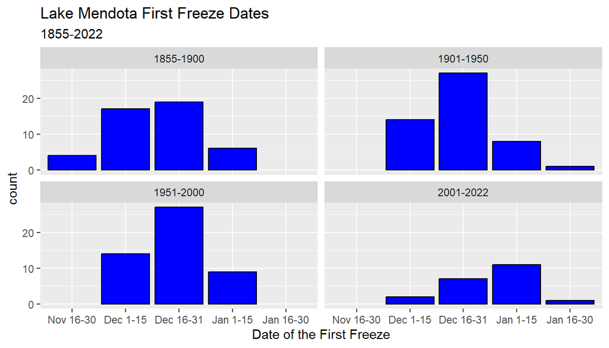

```r
ggplot(mendota, aes(x = ff_period)) +
  geom_bar(color = "black", fill = "blue") +
  xlab("Date of the First Freeze") +
  ggtitle("Lake Mendota First Freeze Dates",
          subtitle = "1855-2022") +
  facet_wrap(vars(period50))
```

- To make it easier to compare the histograms, we may have wanted to display percentages in each group rather than the raw counts.
- Here we use the summary data and plot the percentages from `pct` on the y axis
- This makes it easier to compare the bar graphs ignoring the differences in the total number of observations

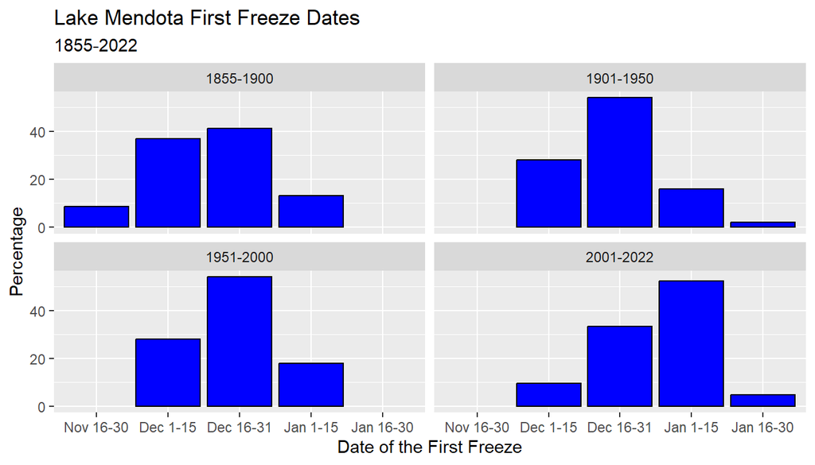

```r
ggplot(mendota_sum2, aes(x = ff_period, y = pct)) +
  geom_col(color = "black", fill = "blue") +
  xlab("Date of the First Freeze") +
  ylab("Percentage") +
  ggtitle("Lake Mendota First Freeze Dates",
          subtitle = "1855-2022") +
  facet_wrap(vars(period50))
```

- Finally, this last graph introduces the command `scale_y_continuous()` to change the labels on the y axis to percentages
- Note that we use the proportions (between 0 and 1) as the data (`y = p`), but that changing the labels to percentages adjusts by multiplying by 100 automatically.

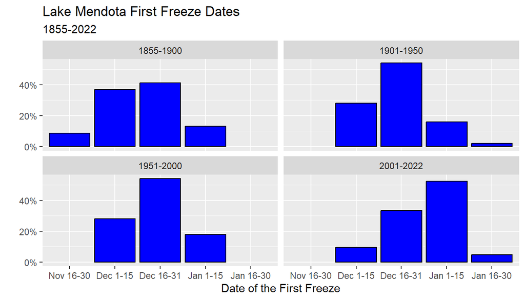

```r
ggplot(mendota_sum2, aes(x = ff_period, y = p)) +
  geom_col(color = "black", fill = "blue") +
  scale_y_continuous(labels = scales::percent) +
  xlab("Date of the First Freeze") +
  ylab("") +
  ggtitle("Lake Mendota First Freeze Dates",
          subtitle = "1855-2022") +
  facet_wrap(vars(period50))
```

- We will see many other changes to scales in future lectures.
- Other examples of `scale_*()` commands include `scale_y_discrete()`, `scale_x_continuous()`, `scale_x_discrete()`.
- The continuous scale commands can be used to change the scales after transformations, such as using logarithmic scales
- These commands can also be used to modify where the and how the axes are labelled.
- Here is an example which replaces the `ff_after_june_30` values (number of days after June 30) with the actual dates.
- Note also the use of saving a `ggplot()` object and then reusing it
  - This is handy when you want to reuse most of the commands for several plots.

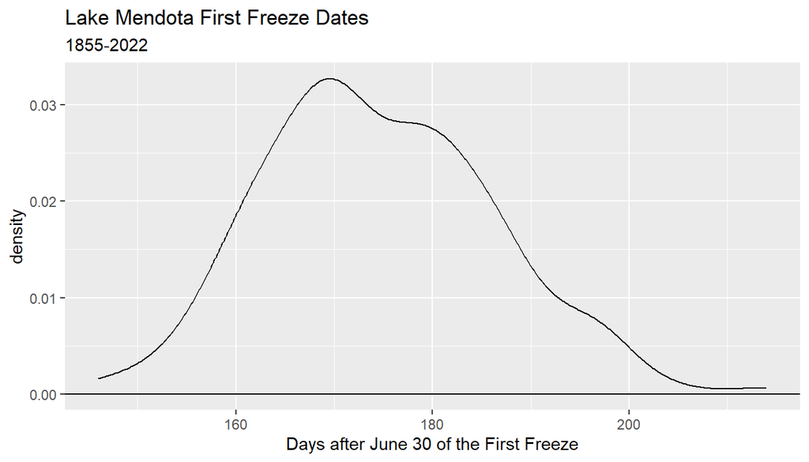

```r
## ff_after_june_30 directly
g = ggplot(mendota, aes(x = ff_after_june_30)) +
  geom_density() +
  geom_hline(yintercept = 0) +
  xlab("Days after June 30 of the First Freeze") +
  ggtitle("Lake Mendota First Freeze Dates",
          subtitle = "1855-2022")

g
```

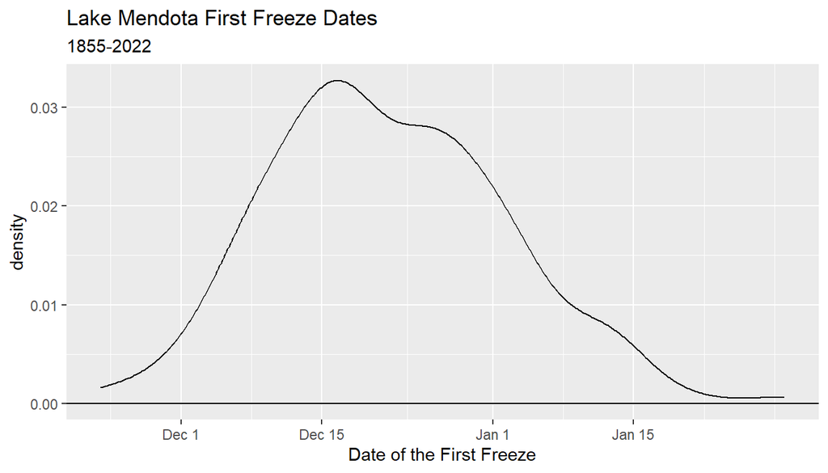

```r
## relabeled axes
## lubridate commands (ignore for now!)
dec01 = as.numeric(ymd("2022-12-01") - ymd("2022-06-30"))
dec15 = as.numeric(ymd("2022-12-15") - ymd("2022-06-30"))
jan01 = as.numeric(ymd("2023-01-01") - ymd("2022-06-30"))
jan15 = as.numeric(ymd("2023-01-15") - ymd("2022-06-30"))

g +
  scale_x_continuous(breaks = c(dec01, dec15, jan01, jan15),
                     labels = c("Dec 1", "Dec 15", "Jan 1", "Jan 15")) +
  xlab("Date of the First Freeze")
```

- There are also `scale_*()` commands for other aesthetics such as color, fill, and size.

### Adding Color

- Color is a useful aesthetic which can be used to add information from a categorical variable (and sometimes a numerical variable) to a plot.
- Here, we make a trace plot of the total duration that Lake Mendota is closed by ice versus the year, but add color to indicate the half-month period of time of the date when Lake Mendota was first closed by ice

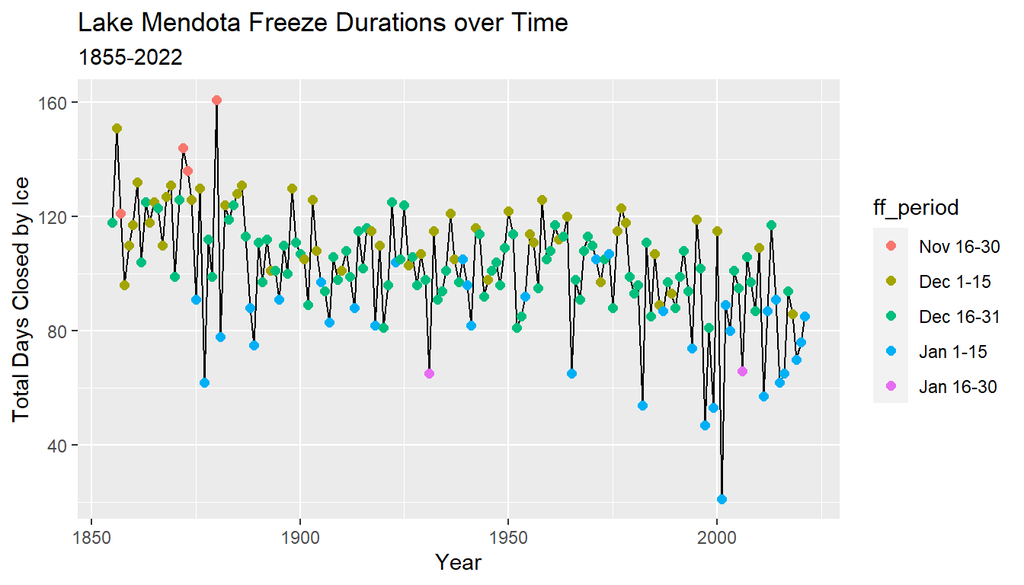

```r
g = ggplot(mendota, aes(x = year1, y = duration)) +
  geom_line() +
  geom_point(aes(col = ff_period), size = 2) +
  xlab("Year") +
  ylab("Total Days Closed by Ice") +
  ggtitle("Lake Mendota Freeze Durations over Time",
          subtitle = "1855-2022")

g
```

- The default color scheme in `ggplot2` is not friendly to color blind people.
  - Red and green are difficult for many people to discern, and these are two colors in the default scale.
- This example uses colors from a scale named “viridis” designed to more evenly spread colors across a continuous range for which the perceptions are similar for most types of color blindness.

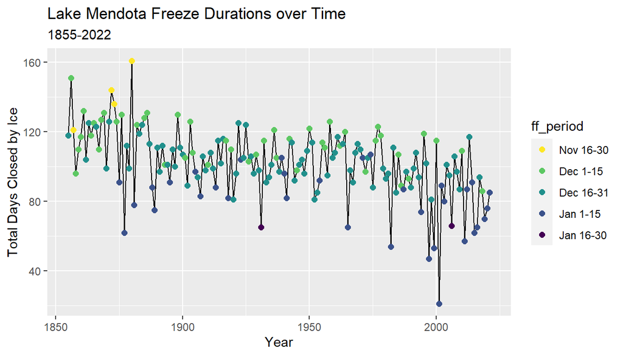

```r
g = g +
  scale_color_viridis_d(direction = -1)

g
```

### Guides

- We make a few other improvements to the plot
- The legend title uses the local variable name `ff_period`. A better choice for presentation would be something like “First Freeze Time”.
- The command `guides()` allows many customization of the legends (guides) which accompany plots.
- The example here changes the title of the color guide.

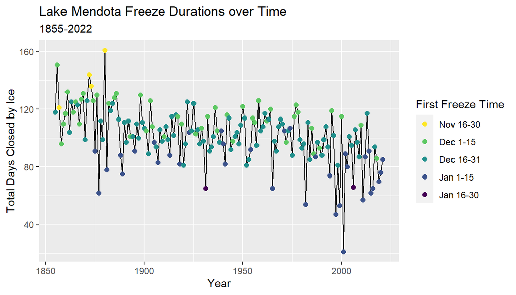

```r
g = g +
  guides(color = guide_legend(title = "First Freeze Time"))

g
```

- More examples on modifying the guides with a plot are in the [tidyverse reference guides page](https://ggplot2.tidyverse.org/reference/guides.html)

### Themes

- The default theme for plots in **ggplot2** uses a gray background with white lines to display breaks
- There are many different themes to choose from
- Here is an example which switches to a black and white these with a white background and light gray break lines

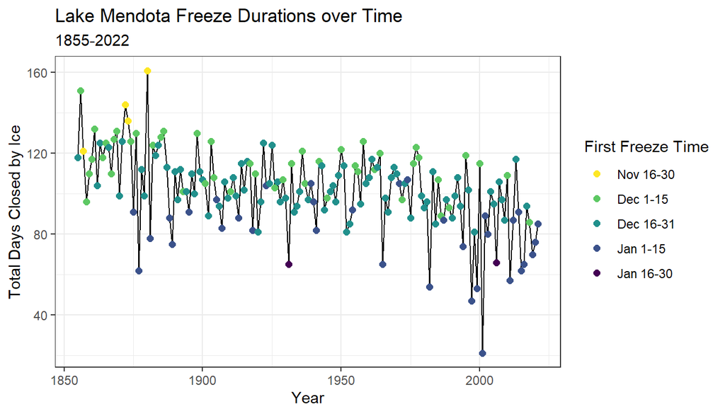

```r
g + theme_bw()
```

- An alternative is a minimal theme which eliminates the box which outlines the plotting area.

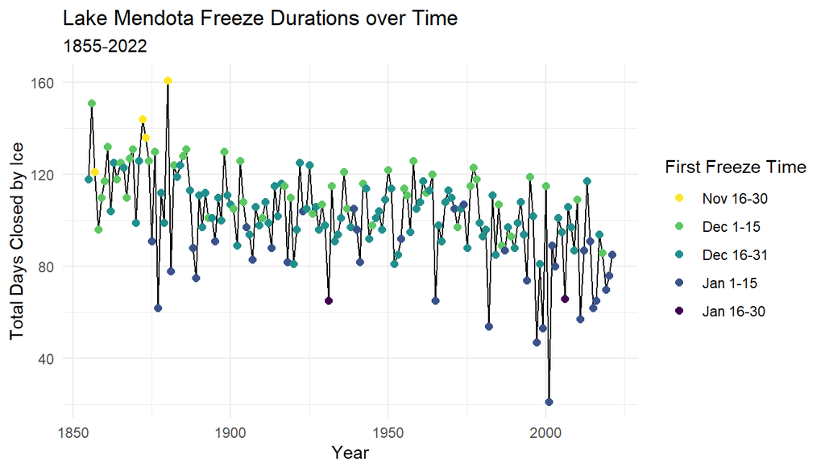

```r
g + theme_minimal()
```

- The [tidyverse list of complete themes](https://ggplot2.tidyverse.org/reference/ggtheme.html) are part of the tidyverse online reference.
- More examples on modifying themes are in the [tidyverse reference guides page](https://ggplot2.tidyverse.org/reference/theme.html)

## Summary

- Plotting is an essential component of data analysis
  - We will practice the **ggplot2** skills you are just now learning throughout the semester
  - We will continue to learn new enhancements to the collection of **ggplot2** commands as the semester continues, even while we focus on learning other aspects of data analysis

### Basics

- Begin all plots with `ggplot()`
  - Typically the call to `ggplot()` will specify:
    - the data set (`data` is the first argument), and
    - the mapping of variables to aesthetics with `aes()` (`mapping` is the second argument)

### Aesthetics

- Aesthetics such as `x`, `y`, `color`, `size`, and `shape` which vary according to the values of variables are mapped to these variables with the function `aes()`
  - Mappings in `ggplot()` carry over to all subsequent layers
  - Aesthetics may be added or replaced with the mapping argument in a specific layer command

### Geoms

- There are different “geometries” which define how data is presented
- Examples we have seen so far include:
  - Histograms with `geom_histogram()`
  - Density plots with `geom_density()`
  - Box plots with `geom_boxplot()`
  - Scatter plots with `geom_point()`
  - Trace plots with `geom_line()`
  - Bar graphs with `geom_bar()` when the function does the counting
  - Bar graphs with `geom_col()` when you supply the bar heights
- There are many more examples.

### Facets

- A single plot may partition the data into parts and display each part in its own facet (panel)
- Use `facet_wrap()` to display a sequence of facets in rows, letting the computer decide where to break the rows
- Use `facet_grid()` when you want to decide which variables vary by rows and columns in the displays

### Color

- You can use color to add information from categorical variables (typically, but numerical sometimes too) to points, lines, or other geometries (such as fill color in box plots)
- Consider using `viridis` or other color sales regularly instead of default values

### Scales

- Functions such as `scale_y_continuous()`, `scale_x_discrete()` and `scale_color_discrete()` (among many others) can maodify the defaults for how aesthetics are displayed in a plot.
- We will see more during the semester
- There are many more features than we will cover this semester.

### Guides

- Use the `guides()` function to control the guides for aesthetics in a plot
  - We have shown how to change a title
  - There are many more features which can be changed

### Themes

- The standard theme has a gray background and white break lines
- `theme_bw()` changes to a black and white theme
- `theme_minimal()` removes the boundary box around the plot and also uses a black and white theme
- There are many, many more options and you can customize

### ggplot2 Reference

- A comprehensive online reference for ggplot 2 is part of the tidyverse.org web site at (https://ggplot2.tidyverse.org/reference/index.html)